# Présentation du projet

Dans ce travail il s'agit de tester la réalité d'une relation linéaire entre la consommation, le revenu disponible, le taux de chômage et les prix de la forme:

$$CPC_t = cste + \alpha RD + \beta TCHO + \gamma PC + \epsilon_t $$

Nous utiliserons pour cela une base de donnée qui contient 39 indicateurs économiques concernant la France entre 1963 et 2012.

## Plan du travail

Pour ce projet je travaillerai avec le langage R, j'ai déjà fait un projet similaire avec Python et SAS. Nous commencerons par lire la base de donnée, la nettoyer afin de la rendre accessible pour nos études économétriques.  
Ensuite nous ferons des statistiques descriptives, suivie d'une série de visualisation des séries temporelles enfin nous construirons plusieurs modèles que nous testerons et évalueront tant pour voir leur fiabilité économétrique que la confrontation des résultats avec la réalité.

```r
# Chargement des librairies nécessaires
library(tidyverse) # Ecosystème data science de R
library(broom) # Pour transformer les résultats en tableau
library(xlsx) # Pour lire les fichiers excel
```

# Lecture et exploration de la base

## Lecture

```r
# Lecture de la base
base <- read.xlsx("DATABASE1963-2012.xls", sheetIndex = 1)
```

```r
# Voyons comment se présente la base de donnée
head(base)
```

| OBS | UN | NA. | CPC | DAT | DLT | DP | DSPS | DUC | GPG | ... | TDE | TE | TINFL | TPRES | TR | TSP | W | XPX | YPY | TEF |
| --- | --- | --- | --- | --- | --- | --- | --- | --- | --- | --- | --- | --- | --- | --- | --- | --- | --- | --- | --- | --- |
| 1 | 1 | 1963-1 | 274.2524 | 1859.227 | 40 | 14.99941 | 4.5757184 | 82.79830 | 103.4027 | ... | 25.20712 | 19.54754 | 5.160079 | 32.01912 | 6.465074 | -0.1421494 | 0.7593375 | 33.28960 | 476.0462 | 8.815188 |
| 2 | 1 | 1963-2 | 279.9798 | 1876.450 | 40 | 16.07585 | 1.5883634 | 84.32867 | 105.2879 | ... | 25.91950 | 18.99050 | 4.982553 | 32.54123 | 6.482865 | 0.3026590 | 0.7674266 | 33.19769 | 486.8920 | 7.582511 |
| 3 | 1 | 1963-3 | 284.8972 | 1887.905 | 40 | 16.90177 | -0.3263631 | 85.18203 | 107.0889 | ... | 26.34562 | 18.64045 | 4.705747 | 32.95577 | 6.457475 | 0.6164599 | 0.7765218 | 33.45203 | 496.4622 | 6.721496 |
| 4 | 1 | 1963-4 | 289.1304 | 1894.530 | 40 | 17.50522 | -1.3548483 | 85.47708 | 108.8094 | ... | 26.51827 | 18.46521 | 4.357520 | 33.27475 | 6.402607 | 0.8160795 | 0.7865479 | 33.99543 | 504.9533 | 6.172891 |
| 5 | 1 | 1964-1 | 292.7529 | 1897.267 | 40 | 17.90968 | -1.6872370 | 85.34056 | 110.4272 | ... | 26.47336 | 18.43138 | 3.972974 | 33.50723 | 6.333507 | 0.9177621 | 0.7972459 | 34.75530 | 512.4495 | 5.879116 |
| 6 | 1 | 1964-2 | 295.9304 | 1897.204 | 40 | 18.15220 | -1.5361318 | 84.90568 | 111.9578 | ... | 26.25108 | 18.50161 | 3.579333 | 33.66943 | 6.264051 | 0.9422764 | 0.8085719 | 35.67072 | 519.2204 | 5.770467 |

A première vue, il y a plusieurs colonnes dans la base de donnée.

```r
dim(base)
```

1. 200

2. 39

Il y a donc en total 200 observations et 39 variables dans cette base de donnée.  
La colonne `NA.` semble représenter des dates, mais de par leur format R ne la considère pas comme telle, il nous faudra donc la transformer manuellement pour indiquer des dates, cela est d'autant plus important que notre base de donnée est une série temporelle.  
Les colonnes `OBS` et `UN` ne sont pas des indicateurs et n'aideront pas donc on peut les enlever.

## Nettoyage de la base de donnée

Nous voulons maintenant connaître les types des données qui se trouvent dans notre base (comment R les a lues).

```r
base %>% sapply(class) %>% unique
```

1. 'numeric'

2. 'factor'

Il y a donc sur cs 39 variables que deux types de données, les données numériques et les facteurs (pour des données catégorielles). Toutes les variables que nous avons dans la base sont en effets quantitatives donc il est normal que R les ait considérées comme numériques; toutefois il n'y a pas de donnée catégorielle ici. Regardons quelle colonne est lue comme un factor.

```r
base[base %>% sapply(class) == "factor"] %>% head()
```

| NA. |
| --- |
| 1963-1 |
| 1963-2 |
| 1963-3 |
| 1963-4 |
| 1964-1 |
| 1964-2 |

C'est donc la colonne `NA.` qui est lue comme catégorique, c'est dû au format `Année-Trimestre`. Nous allons donc corriger cela

La solution la plus facile est de créer une nouvelle variable `Temps` qui simule le même comportement que notre variable `NA`, c'est à dire qui divise une année en 4 périodes de temps. Etant donnée donc que nous avons 200 observations dans le base, il y a donc 200 périodes de temps entre le 1963 et 2012.

```r
base$Temps <- seq(from = as.Date("1963-1-01"), to = as.Date("2012-12-30"), length.out = 200)
```

```r
# Regardons
base["Temps"] %>% head()
```

| Temps |
| --- |
| 1963-01-01 |
| 1963-04-02 |
| 1963-07-03 |
| 1963-10-03 |
| 1964-01-03 |
| 1964-04-03 |

Nous avons corrigé le problème en créant la variable `Temps`. Nous pouvons maintenant enlever les variables inutiles

```r
base <- base %>% select(-c("NA.", "OBS", "UN"))
```

```r
dim(base)
```

1. 200

2. 37

# Statistiques descriptives

Commençons maintenant les statistiques descriptives. Le but de cette partie est de comprendre la distribution des variables que nous sélectionnerons pour cette étude, à savoir la consommation `CPC`, le revenu disponible `RD`, le taux de chomage `TCHO` ainsi que les prix de la consommation `PC`.  
Nous commencerons donc à ne sélectionner que les variables que nous utiliserons

```r
estimation <- base %>% select(c("Temps", "CPC", "RD", "TCHO", "PC"))
head(estimation)
```

| Temps | CPC | RD | TCHO | PC |
| --- | --- | --- | --- | --- |
| 1963-01-01 | 274.2524 | 323.8444 | 1.792245 | 12.69186 |
| 1963-04-02 | 279.9798 | 328.4966 | 1.528324 | 12.84683 |
| 1963-07-03 | 284.8972 | 332.8224 | 1.400138 | 12.98270 |
| 1963-10-03 | 289.1304 | 336.8932 | 1.382234 | 13.10261 |
| 1964-01-03 | 292.7529 | 340.7208 | 1.446916 | 13.20812 |
| 1964-04-03 | 295.9304 | 344.4050 | 1.566144 | 13.30341 |

```r
estimation %>% summarytools::descr(transpose = T)
```

|  | Mean | Std.Dev | Min | Q1 | Median | Q3 | Max | MAD | IQR | CV | Skewness | SE.Skewness | Kurtosis | N.Valid | Pct.Valid |
| --- | --- | --- | --- | --- | --- | --- | --- | --- | --- | --- | --- | --- | --- | --- | --- |
| CPC | 667.976435 | 219.857030 | 274.252399 | 484.792327 | 678.466020 | 856.128991 | 1013.8380 | 274.170341 | 368.439822 | 0.3291389 | -0.06036115 | 0.1719248 | -1.108796 | 200 | 100 |
| RD | 707.388785 | 203.283031 | 323.844394 | 570.776089 | 684.748226 | 888.219209 | 1025.2256 | 207.644587 | 314.391775 | 0.2873710 | -0.05701856 | 0.1719248 | -1.027733 | 200 | 100 |
| TCHO | 6.731115 | 2.994175 | 1.382234 | 3.411772 | 7.944265 | 9.032422 | 10.8391 | 2.922781 | 5.576279 | 0.4448261 | -0.45670320 | 0.1719248 | -1.338530 | 200 | 100 |
| PC | 63.518315 | 34.057961 | 12.691857 | 26.245478 | 73.386522 | 91.439985 | 112.6875 | 41.138641 | 64.871816 | 0.5361912 | -0.26155355 | 0.1719248 | -1.496006 | 200 | 100 |

Nous pouvons maintenant les représenter graphiquement à l'aide d'histogrammes.

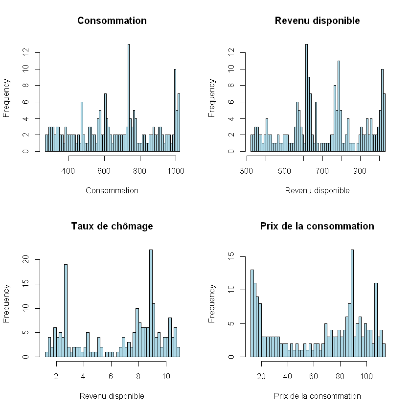

```r
par(mfrow=c(2,2))
hist(estimation$CPC, main = "Consommation", xlab = "Consommation", col = "lightblue", breaks = 60)
hist(estimation$RD, main = "Revenu disponible", xlab = "Revenu disponible", col = "lightblue", breaks = 60)
hist(estimation$TCHO, main = "Taux de chômage", xlab = "Revenu disponible", col = "lightblue", breaks = 60)
hist(estimation$PC, main = "Prix de la consommation", xlab = "Prix de la consommation", col = "lightblue", breaks = 60)
```

## Quelle correlations entre les variables

```r
library(ggcorrplot)
```

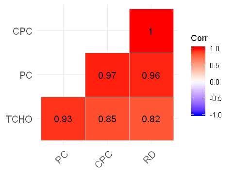

```r
options(repr.plot.height = 3, repr.plot.width = 4) # Taille de l'image
estimation[estimation %>% sapply(is.numeric)] %>% cor() %>% ggcorrplot(hc.order = TRUE, type = "lower",
   lab = TRUE)
```

Il y a une très forte correlation entre les variables.  
la consommation (`CPC`) corrèle parfaitement avec le revenu disponible (`RD`), et ainsi de suite pour la lecture de ce graphique.

# Visualisation des séries temporelles

Dans cette partie nous allons voir l'évolution des variables avec le temps.

```r
options(repr.plot.height = 4, repr.plot.width = 7) # Taille de l'image
```

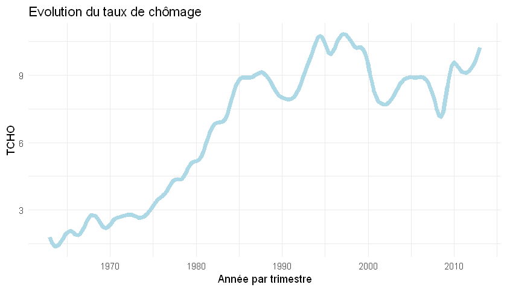

```r
estimation %>% ggplot(aes(x= Temps, y=TCHO)) + geom_line(col = "lightblue", lwd = 2) + theme_minimal() +
xlab("Année par trimestre") + ggtitle("Evolution du taux de chômage")
```

On observe que depuis les année 1970 le taux de chômage n'a cessé de croître avec de légères variations pour atteindre un niveau maximal d'environs 10% dans les années 1995 et ensuite commencer à chuter pour stagner autour des 9%.

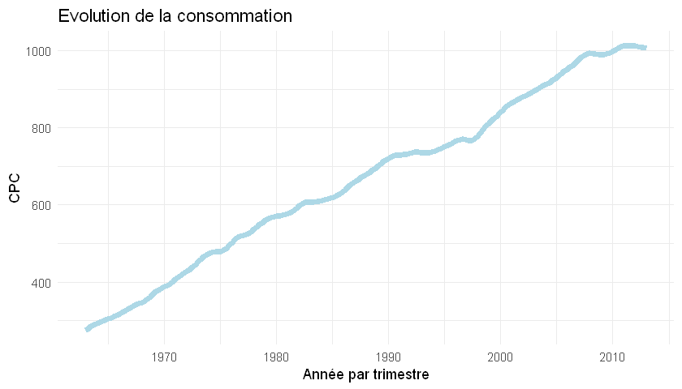

```r
estimation %>% ggplot(aes(x= Temps, y=CPC)) + geom_line(col = "lightblue", lwd = 2) + theme_minimal() +
xlab("Année par trimestre") + ggtitle("Evolution de la consommation")
```

La consommation croît positivement avec le temps. Depuis le début des années 70 la courbe est ressemble à une droite avec une pente stable.

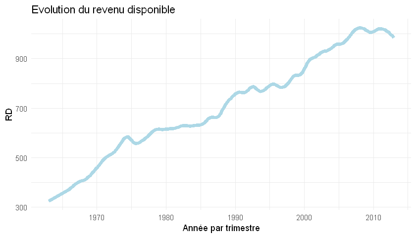

```r
estimation %>% ggplot(aes(x= Temps, y=RD)) + geom_line(col = "lightblue", lwd = 2) + theme_minimal() +
xlab("Année par trimestre") + ggtitle("Evolution du revenu disponible")
```

Le revenu disponible suit une tendance croissante comme la consommation mais il varie un peu plus. On observe sur toute la période que la courbe fluctue plusiseurs fois.

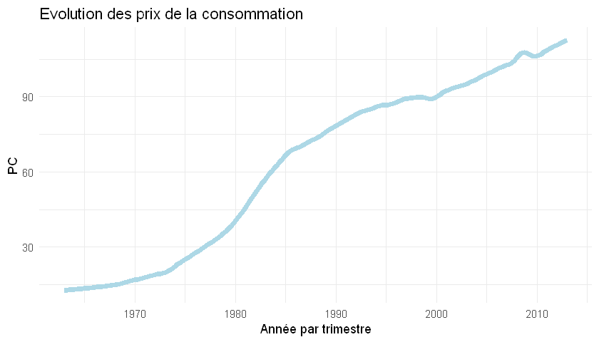

```r
estimation %>% ggplot(aes(x= Temps, y=PC)) + geom_line(col = "lightblue", lwd = 2) + theme_minimal() +
xlab("Année par trimestre") + ggtitle("Evolution des prix de la consommation")
```

L'évolution des prix de la consommation est beaucoup plus brusque que celle des autres variables. Elle semble convexe entre les années 1963 à 1983 année à laquelle l'évolution bascule pour ressembler pour ressembler à une fonction concave.

# Construction des modèles économétriques

Nous allons estimer un modèle de regression multiple avec pour variable endogène la consommation et comme variables exogènes toutes les autres variables que nous avions sélectionnées.

## Modèle de regression multiple

```r
premier_modele <- lm(CPC~RD+TCHO+PC, data = estimation)
```

```r
summary(premier_modele)
```

```
Call:
lm(formula = CPC ~ RD + TCHO + PC, data = estimation)

Residuals:
    Min      1Q  Median      3Q     Max
-28.585  -8.638   0.815   9.225  32.635

Coefficients:
            Estimate Std. Error t value Pr(>|t|)
(Intercept) -4.68602    7.88069  -0.595   0.5528
RD           0.80156    0.01925  41.645   <2e-16 ***
TCHO        -1.70471    0.97613  -1.746   0.0823 .
PC           1.84393    0.17334  10.637   <2e-16 ***
---
Signif. codes:  0 '***' 0.001 '**' 0.01 '*' 0.05 '.' 0.1 ' ' 1

Residual standard error: 12.19 on 196 degrees of freedom
Multiple R-squared:  0.997,	Adjusted R-squared:  0.9969
F-statistic: 2.153e+04 on 3 and 196 DF,  p-value: < 2.2e-16
```

La significativité globale de notre modèle est très bonne, on peut rejeter l'hypothèse de nullité des coefficients exprimée par le test de Fisher au seuil de 1%.
L'équation du modèle est la suivante: $$CPC = -4.68 + 0.8RD -1.7TCHO + 1.84PC$$

Les variables RD et PC sont significatives au seuil de 1% mais la variable TCHO l'est au seuil de 10%.

```r
# L'intervalle de confiance
confint.lm(premier_modele, level = 0.95)
```

|  | 2.5 % | 97.5 % |
| --- | --- | --- |
| (Intercept) | -20.2278450 | 10.8558113 |
| RD | 0.7636006 | 0.8395179 |
| TCHO | -3.6297807 | 0.2203590 |
| PC | 1.5020652 | 2.1857855 |

### Analyse des résidus

Les informations que nous avions eu plus haut seraient suffisantes si nous voulions juste avoir les coefficients, mais étant donnée que nous sommes dans une équations macroéconométrique sur laquelle nous pouvons faire des prévisions nous devons nous assurer que les résidus sont des bruits blancs.

```r
residus <- premier_modele %>% augment_columns(estimation)
head(residus)
```

| Temps | CPC | RD | TCHO | PC | .fitted | .se.fit | .resid | .hat | .sigma | .cooksd | .std.resid |
| --- | --- | --- | --- | --- | --- | --- | --- | --- | --- | --- | --- |
| 1963-01-01 | 274.2524 | 323.8444 | 1.792245 | 12.69186 | 275.2420 | 2.819354 | -0.9896308 | 0.05353170 | 12.21651 | 9.853649e-05 | -0.08347878 |
| 1963-04-02 | 279.9798 | 328.4966 | 1.528324 | 12.84683 | 279.7068 | 2.947715 | 0.2730607 | 0.05851709 | 12.21671 | 8.287588e-06 | 0.02309452 |
| 1963-07-03 | 284.8972 | 332.8224 | 1.400138 | 12.98270 | 283.6431 | 2.990947 | 1.2540397 | 0.06024616 | 12.21637 | 1.806240e-04 | 0.10615982 |
| 1963-10-03 | 289.1304 | 336.8932 | 1.382234 | 13.10261 | 287.1578 | 2.957962 | 1.9726530 | 0.05892465 | 12.21586 | 4.359146e-04 | 0.16687620 |
| 1964-01-03 | 292.7529 | 340.7208 | 1.446916 | 13.20812 | 290.3101 | 2.867414 | 2.4427583 | 0.05537231 | 12.21540 | 6.234249e-04 | 0.20625575 |
| 1964-04-03 | 295.9304 | 344.4050 | 1.566144 | 13.30341 | 293.2357 | 2.740286 | 2.6947248 | 0.05057123 | 12.21512 | 6.858978e-04 | 0.22695468 |

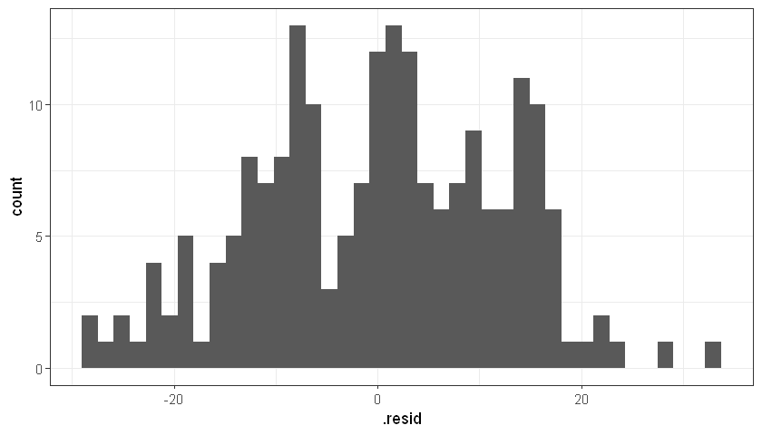

```r
residus %>% ggplot(aes(.resid)) + geom_histogram(bins=40) + theme_bw()
```

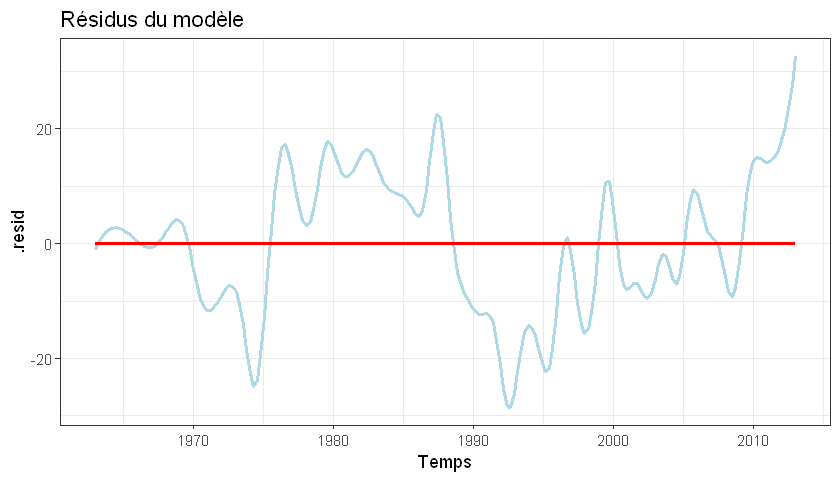

```r
residus %>% ggplot(aes(x= Temps, y= .resid)) + geom_line(col = "lightblue", lwd=1) + theme_bw() +
geom_line(y=0, col = 'red', lwd = 1) + ggtitle("Résidus du modèle")
```

```r
library(Metrics)
```

### Root Mean Square Error

```r
rmse(residus$CPC, residus$.fitted)
```

12.0630497980602

```r
smape(residus$CPC, residus$.fitted)
```

0.0152266148631396

### Autocorrelation des résidus

On se demande donc ici est-ce qu'il y a autocorrelation entre les résidus de ce modèle. Pour tester cela utilisons le test de Durbin-Watson

```r
library(lmtest)
```

```r
lmtest::dwtest(CPC~RD+TCHO+PC, data=estimation)
```

```
	Durbin-Watson test

data:  CPC ~ RD + TCHO + PC
DW = 0.052997, p-value < 2.2e-16
alternative hypothesis: true autocorrelation is greater than 0
```

La valeur du Durbin-Watson st comprise entre 0 et 4. Si elle est de 2 c'est qu'il n'y a aucune autocorrelation, autrement il y a une autocorrelation, c'est le cas pour notre modèle.

### Capacité de prédiction

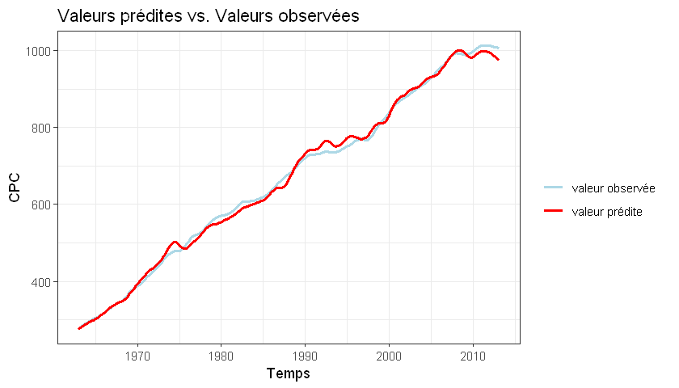

```r
residus %>% ggplot(aes(x= Temps)) + geom_line(aes(y = CPC, col = "valeur observée"), lwd=1) + theme_bw() +
geom_line(aes(y= .fitted, col = 'valeur prédite'), lwd=1) + ggtitle("Valeurs prédites vs. Valeurs observées") +
scale_colour_manual("",
                      values = c("valeur observée"="lightblue", "valeur prédite"="red"))
```

## Modèle log-log

Nous allons essayer d'améliorer le modèle en transformant les variables explicatives.
$$ln(CPC) = ln(RD) + ln(TCHO) + ln(PC) $$
Nous allons ajouter à notre base `estimation` de nouvelles variables qui sont les transformations en logarithme de nos variables actuelles exceptée la variable `taux de chômage` qui est déjà en pourcentage.

```r
estimation$LCPC <- log(estimation$CPC)
estimation$LRD <- log(estimation$RD)
estimation$LPC <- log(estimation$PC)
head(estimation)
```

| Temps | CPC | RD | TCHO | PC | LCPC | LRD | LPC |
| --- | --- | --- | --- | --- | --- | --- | --- |
| 1963-01-01 | 274.2524 | 323.8444 | 1.792245 | 12.69186 | 5.614049 | 5.780263 | 2.540961 |
| 1963-04-02 | 279.9798 | 328.4966 | 1.528324 | 12.84683 | 5.634718 | 5.794527 | 2.553097 |
| 1963-07-03 | 284.8972 | 332.8224 | 1.400138 | 12.98270 | 5.652128 | 5.807609 | 2.563618 |
| 1963-10-03 | 289.1304 | 336.8932 | 1.382234 | 13.10261 | 5.666878 | 5.819766 | 2.572811 |
| 1964-01-03 | 292.7529 | 340.7208 | 1.446916 | 13.20812 | 5.679329 | 5.831063 | 2.580832 |
| 1964-04-03 | 295.9304 | 344.4050 | 1.566144 | 13.30341 | 5.690124 | 5.841818 | 2.588021 |

```r
deuxieme_modele <- lm(LCPC~LRD+TCHO+LPC, data = estimation)
```

```r
summary(deuxieme_modele)
```

```
Call:
lm(formula = LCPC ~ LRD + TCHO + LPC, data = estimation)

Residuals:
      Min        1Q    Median        3Q       Max
-0.041412 -0.009890  0.002624  0.009795  0.045196

Coefficients:
             Estimate Std. Error t value Pr(>|t|)
(Intercept)  0.429485   0.066583    6.45 8.53e-10 ***
LRD          0.826237   0.015005   55.06  < 2e-16 ***
TCHO        -0.004683   0.001620   -2.89  0.00429 **
LPC          0.168025   0.011215   14.98  < 2e-16 ***
---
Signif. codes:  0 '***' 0.001 '**' 0.01 '*' 0.05 '.' 0.1 ' ' 1

Residual standard error: 0.01599 on 196 degrees of freedom
Multiple R-squared:  0.9981,	Adjusted R-squared:  0.9981
F-statistic: 3.465e+04 on 3 and 196 DF,  p-value: < 2.2e-16
```

Le modèle semble bien s'être amélioré après ces transformations car le R² est passé de 0.997 pour le premier modèle à 0.998, en plus la variable taux de chômage est devenue significative au seuil de 5%.

```r
confint.lm(deuxieme_modele)
```

|  | 2.5 % | 97.5 % |
| --- | --- | --- |
| (Intercept) | 0.298173629 | 0.560797323 |
| LRD | 0.796644762 | 0.855828755 |
| TCHO | -0.007878583 | -0.001487393 |
| LPC | 0.145907010 | 0.190142491 |

L'intervalle de confiance s'est amélioré.

```r
residus2 <- deuxieme_modele %>% augment_columns(estimation)
head(residus2)
```

| Temps | CPC | RD | TCHO | PC | LCPC | LRD | LPC | .fitted | .se.fit | .resid | .hat | .sigma | .cooksd | .std.resid |
| --- | --- | --- | --- | --- | --- | --- | --- | --- | --- | --- | --- | --- | --- | --- |
| 1963-01-01 | 274.2524 | 323.8444 | 1.792245 | 12.69186 | 5.614049 | 5.780263 | 2.540961 | 5.623903 | 0.003269913 | -9.853717e-03 | 0.04179738 | 0.01601892 | 4.319677e-03 | -0.6293753779 |
| 1963-04-02 | 279.9798 | 328.4966 | 1.528324 | 12.84683 | 5.634718 | 5.794527 | 2.553097 | 5.638963 | 0.003320157 | -4.245258e-03 | 0.04309174 | 0.01603212 | 8.288546e-04 | -0.2713359325 |
| 1963-07-03 | 284.8972 | 332.8224 | 1.400138 | 12.98270 | 5.652128 | 5.807609 | 2.563618 | 5.652140 | 0.003327550 | -1.154819e-05 | 0.04328385 | 0.01603513 | 6.163174e-09 | -0.0007381775 |
| 1963-10-03 | 289.1304 | 336.8932 | 1.382234 | 13.10261 | 5.666878 | 5.819766 | 2.572811 | 5.663813 | 0.003268791 | 3.064831e-03 | 0.04176871 | 0.01603356 | 4.175805e-04 | 0.1957535975 |
| 1964-01-03 | 292.7529 | 340.7208 | 1.446916 | 13.20812 | 5.679329 | 5.831063 | 2.580832 | 5.674192 | 0.003156478 | 5.136704e-03 | 0.03894773 | 0.01603074 | 1.087362e-03 | 0.3276041522 |
| 1964-04-03 | 295.9304 | 344.4050 | 1.566144 | 13.30341 | 5.690124 | 5.841818 | 2.588021 | 5.683728 | 0.003016515 | 6.396511e-03 | 0.03557030 | 0.01602834 | 1.529147e-03 | 0.4072359959 |

### Résidus du modèle

Je vais utiliser les résidus studentisés pour comparer les erreurs de prédictions pour les deux modèles.

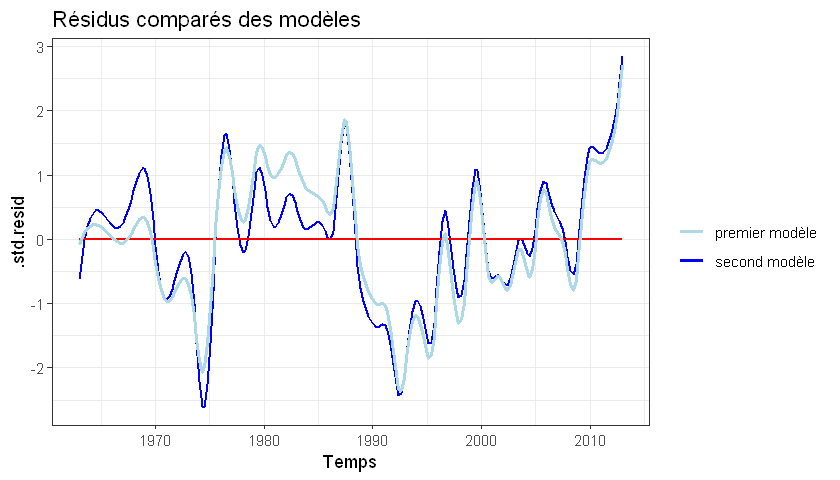

```r
residus2 %>% ggplot(aes(x= Temps, y= .std.resid)) + geom_line(aes(col = "second modèle"), lwd=0.7) + theme_bw() +
geom_line(y=0, col = 'red', lwd = 0.7) + ggtitle("Résidus comparés des modèles") +
geom_line(aes(y= residus$.std.resid, col = "premier modèle"), lwd=1) +
scale_colour_manual("",
                      values = c("premier modèle"="lightblue", "second modèle"="blue"))
```

On observe que le second meilleur semble être meilleur dans les années 1980 mais ne diffère pas sensiblement du premier modèle après.  
Réalisons le test de Durbin-Watson

```r
dwtest(deuxieme_modele)
```

```
	Durbin-Watson test

data:  deuxieme_modele
DW = 0.07159, p-value < 2.2e-16
alternative hypothesis: true autocorrelation is greater than 0
```

Les résidus sont toujours autocorrelés entre eux. Nous verrons dans une prochaine série d'autres techniques pour limiter l'autoccrelation.  
Essayons maintenant de de comparer les valeurs prédites et les valeurs observées. Pour cela nous allons transformer les valeurs prédites en exponentielle pour enlever le logarithme

```r
rmse(residus2$LCPC, residus2$.fitted)
```

0.0158334193049535

```r
smape(residus2$LCPC, residus2$.fitted)
```

0.00191724024839928

```r
residus2$expPREV <- exp(residus2$.fitted)
```

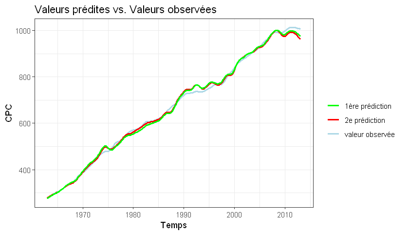

```r
residus2 %>% ggplot(aes(x= Temps)) + geom_line(aes(y = CPC, col = "valeur observée"), lwd=1) + theme_bw() +
geom_line(aes(y= expPREV, col = '2e prédiction'), lwd=1) + ggtitle("Valeurs prédites vs. Valeurs observées") +
geom_line(aes(y= residus$.fitted, col = '1ère prédiction'), lwd=1) +
scale_colour_manual("",
                      values = c("valeur observée"="lightblue", "2e prédiction"="red", "1ère prédiction"="green"))
```